# Otodom Lublin analyse

Antoniuk Davyd

### **Project goal**

The aim of the project was to conduct a comprehensive analysis of the real estate market in Lublin, using data obtained from the OtoDom real estate portal. The main goal was to collect and systematize information from real estate listings in the region.

The main tasks included collecting data on different types of properties, their location, area, prices and other parameters. In addition, for a broader context, data from other cities was also taken to conduct a comparative analysis of real estate markets and identify features that make Lublin unique or similar to other regions.

### **Data base**

As part of the project, I collected and analyzed data on house sale advertisements in Lublin and other Polish cities, using the R programming language. Before proceeding with the analysis, I cleaned the data, removing NA values and outliers. The first database contained ads from Lublin only and consisted of the following columns: city,name,price,price_m2,rooms,area,region,full_address,year_construction,type_construction,material_building

The second database contained ads from different cities: Lublin, Warsaw, Wroclaw, Katowice, Gdansk, Bialystok and consisted of the following columns: city,name,price,price_m2,rooms,area

#### Comparison of the city of Lublin with other cities

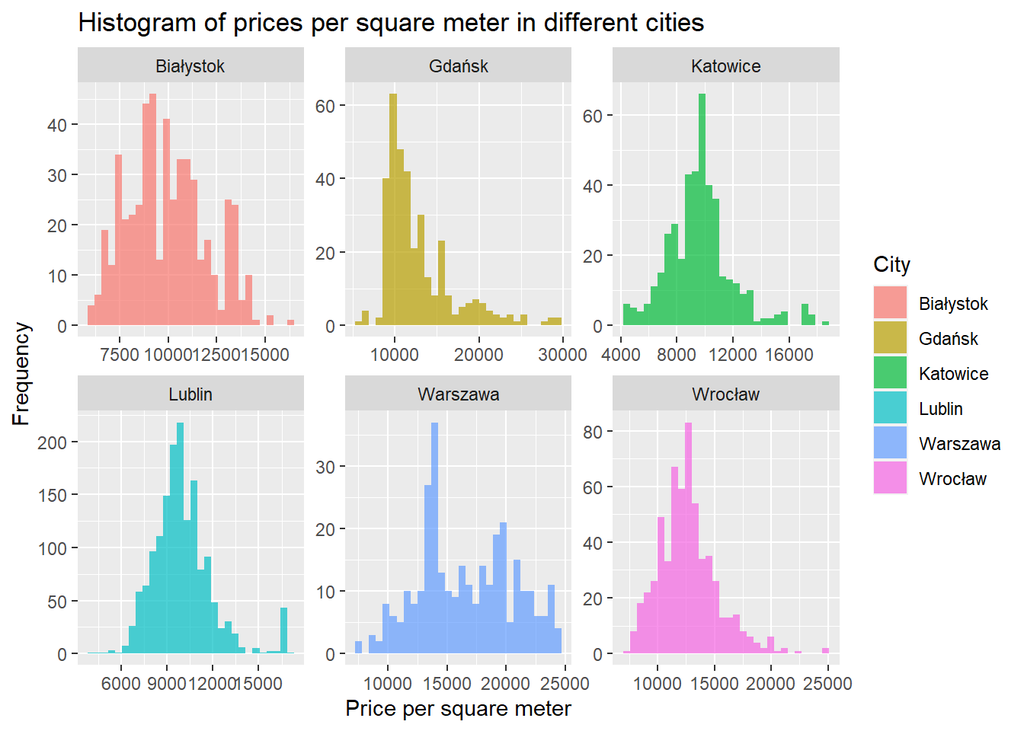

The chart shows the distribution of prices per square meter of real estate in various Polish cities. It shows that the distribution of prices varies considerably between cities, with Warsaw having the highest prices and a wide range, while other cities, such as Bialystok and Lublin, have lower and more concentrated price distributions.

*Warsaw* is the most expensive and most diversified real estate market in Poland, which may be due to its status as the capital, large population, high standard of living and attractiveness to investors.

*Bialystok, Katowice and Lublin* are the cheapest and least diverse real estate markets in Poland, which may be due to their smaller populations, lower living standards and lower attractiveness to investors.

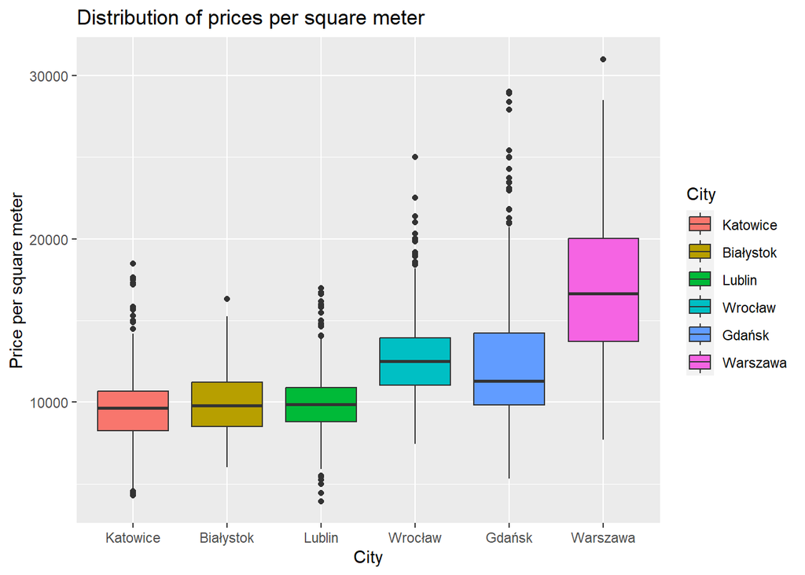

The chart shows the median, interquartile range and outliers of prices per square meter in six cities: Katowice, Bialystok, Lublin, Wroclaw, Gdansk and Warsaw.

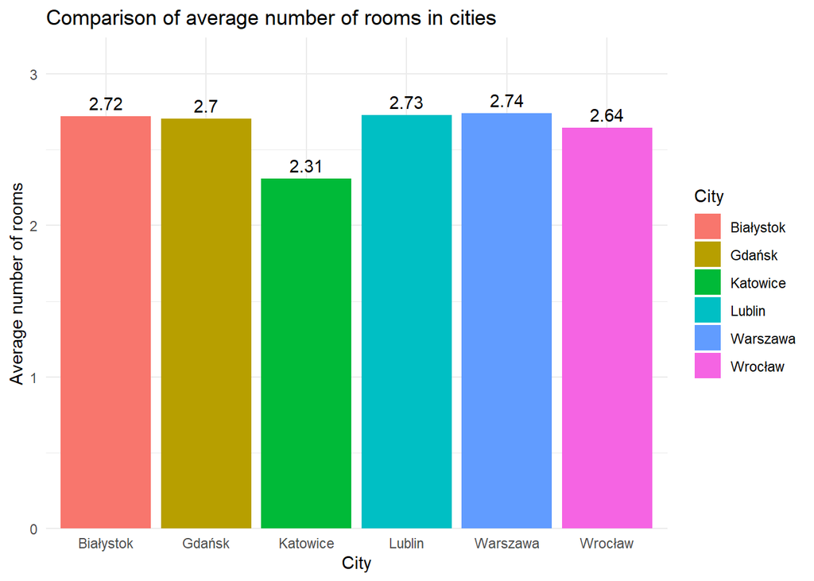

The differences between cities are small. The average number of rooms in all cities ranges from *2.31 to 2.74*, which means that there are no big differences in the size of apartments.

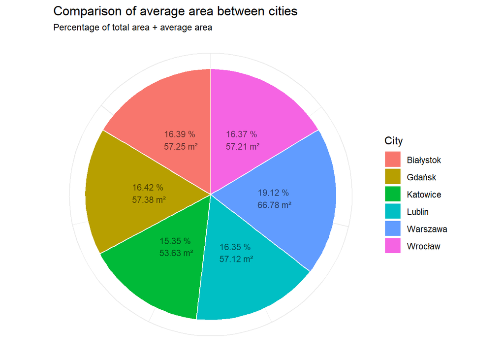

*The differences between cities are moderate.* The average area in all cities ranges from *53.63 m²* to *66.78 m²*, which means that there are no extreme differences in housing size.

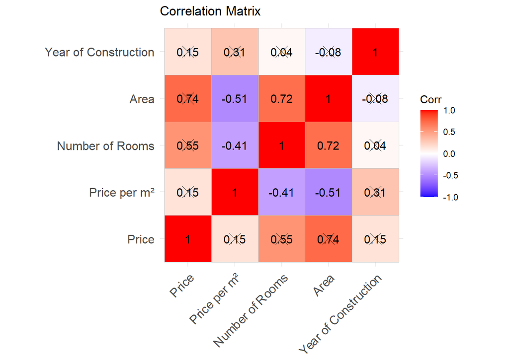

```
## Highest correlation coefficient: 0.74
```

```
## Between variables: Area and Price
```

```
## Lowest correlation coefficient: -0.51
```

```
## Between variables: Area and Price per m²
```

The highest correlation coefficient *(0.74)* between the variables *“Area” (area)* and *“Price” (price)* indicates a strong positive relationship between property size and price. This means that the larger the area of a property, the higher the price usually is.

In contrast, the lowest correlation coefficient *(-0.51)* between the variables *“Area”* and *“Price per m²” (price per square meter)* indicates a moderate negative relationship between property size and price per square meter. This means that although larger properties tend to be more expensive, the price per square meter decreases as the area increases.

#### Analiza w mieście Lublin

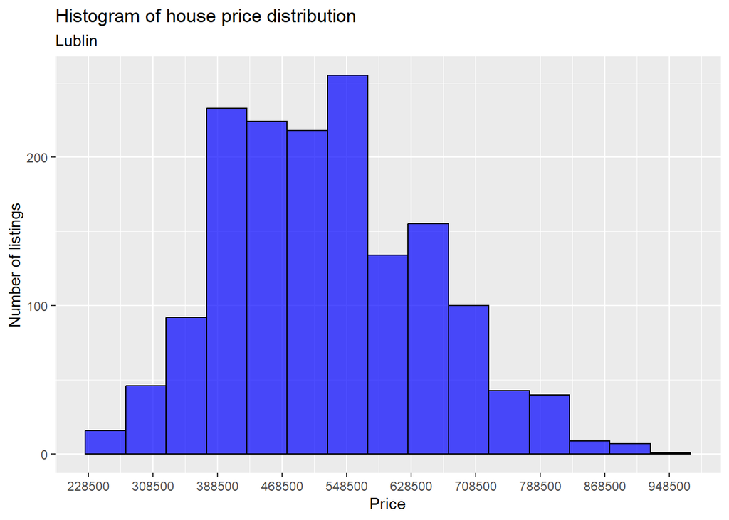

It can be read from it that a significant proportion of homes are priced between *385,050* and *548,500*, with the highest incidence in this range. One can conclude from this that this is the typical price range for houses in Lublin, and that houses with lower or higher prices are rarer or more exclusive.

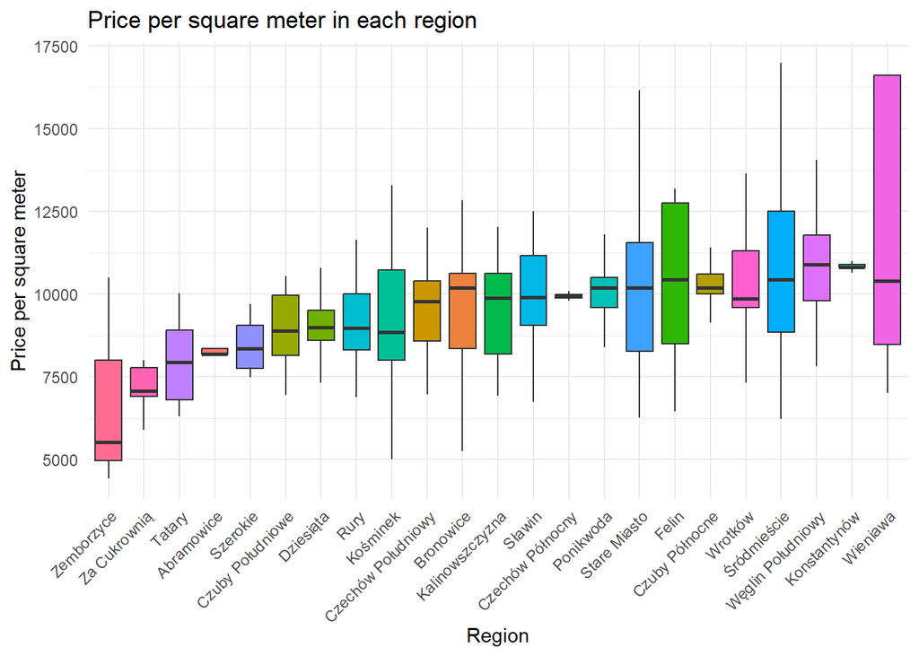

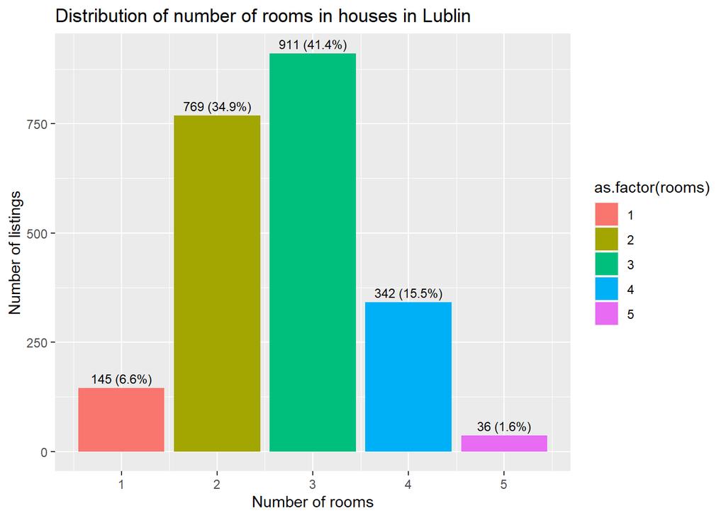

The chart shows the distribution of the number of rooms in houses in Lublin. The largest number of ads are for houses with three rooms *(41.4%)*, and the smallest number of ads are for houses with five rooms *(1.6%)*. It can be concluded from this that three rooms is the most popular and optimal size of a house in Lublin, while houses with more or fewer rooms are less common or less desirable.

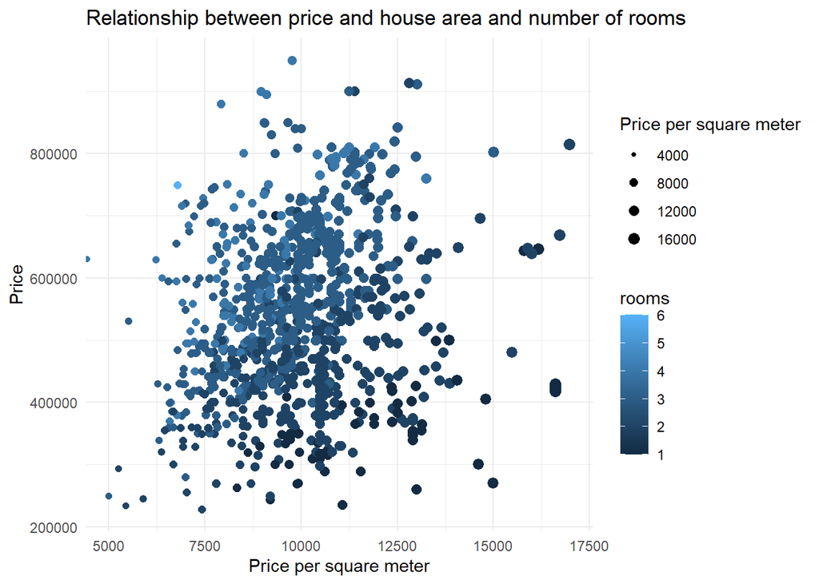

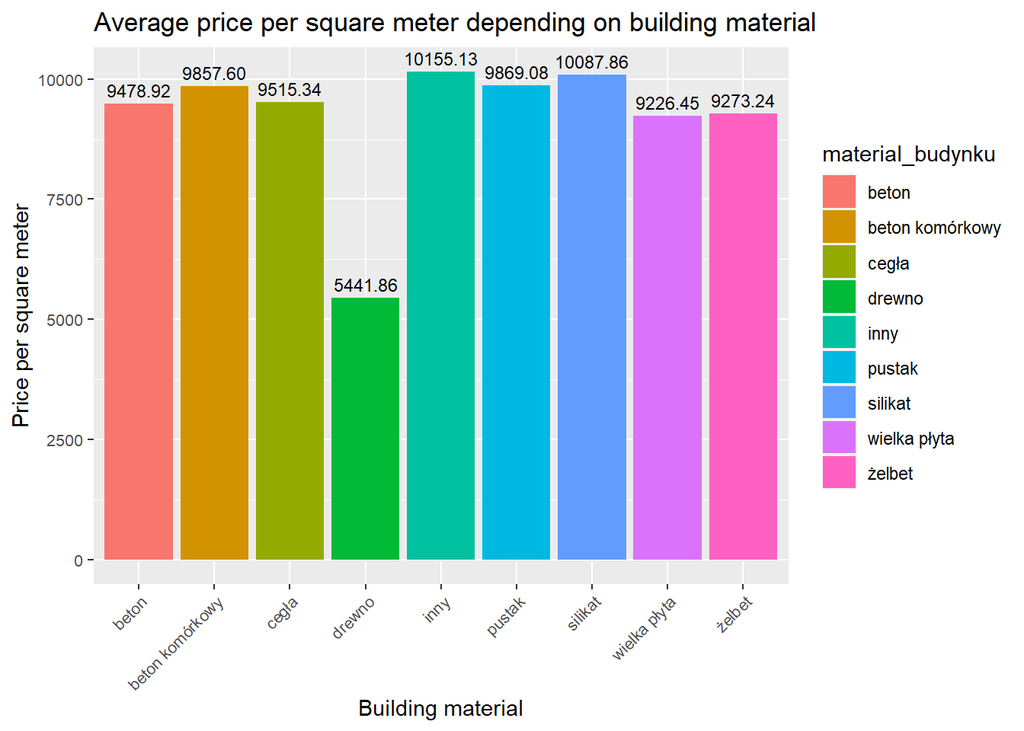

*Timber is the cheapest.* Buildings made of wood have the lowest average price per square meter.

*Concrete and cellular concrete* are similar. Buildings made of concrete and cellular concrete have a similar average price per square meter.

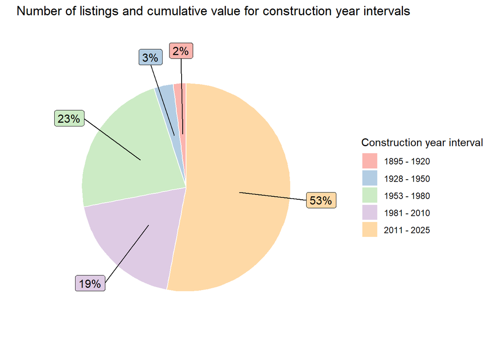

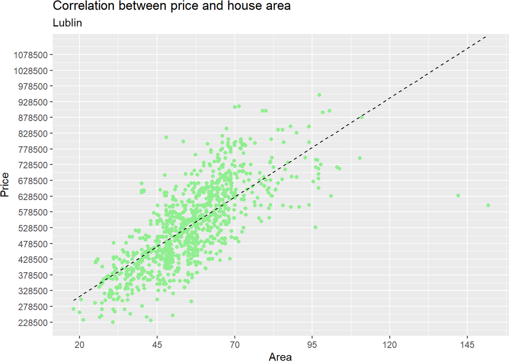

The chart shows that there is a positive correlation between price and area of houses in Lublin, meaning that the larger the house, the more expensive it tends to be. The implication is that demand for large houses is high and supply is low. It is possible that large houses are attractive because of their larger space, better conditions or prestige. Alternatively, small houses may be cheaper, but also less popular or less available.

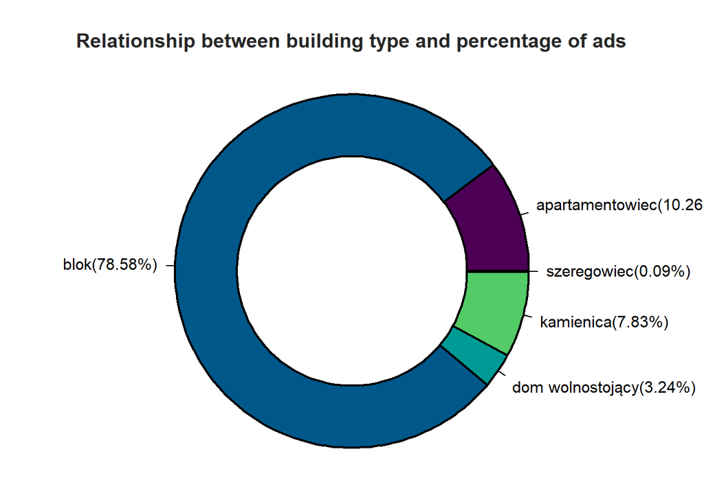

[output not shown]

The chart shows that the majority of ads are for block-type buildings *(78.58%)*, which may imply that these are the most common and affordable housing options. Apartment building type buildings make up the second largest group *(10.26%)*, which may suggest that these are newer and more expensive alternatives. Townhouse-type buildings *(7.83%)* and detached house *(3.24%)* have a much smaller share, which may indicate that these are older and rarer property types. Terraced house type buildings have the smallest share *(0.09%)*, which may indicate that these are very rare and specific offerings.  
**Clustering**  
In my research, I use cluster analysis to study the real estate market in Lublin city in detail. The data I obtained includes information on prices, number of rooms and area of properties. Using the k-means algorithm, I formed clusters to further analyze the distribution of prices according to the number of rooms. I then determined the optimal number of clusters and examined their effect on the distribution of prices per square meter. The results are presented in the form of graphs that show the distribution of prices by number of rooms and the distribution of clusters by area and price per square meter. This gives us an in-depth understanding of the structure of the real estate market and identifies potential patterns that can be useful to investors and developers.

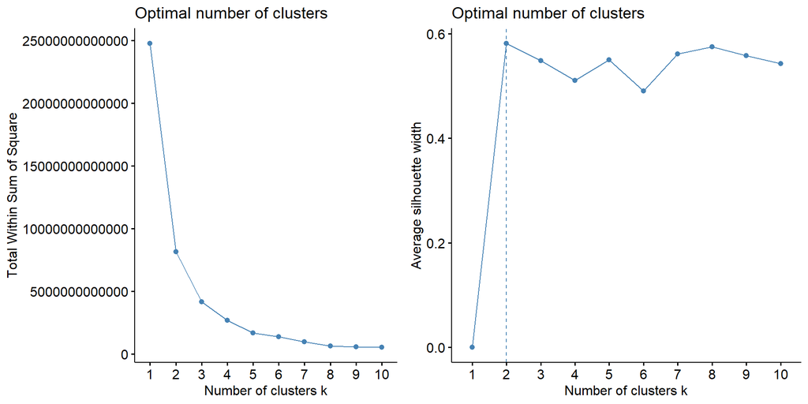

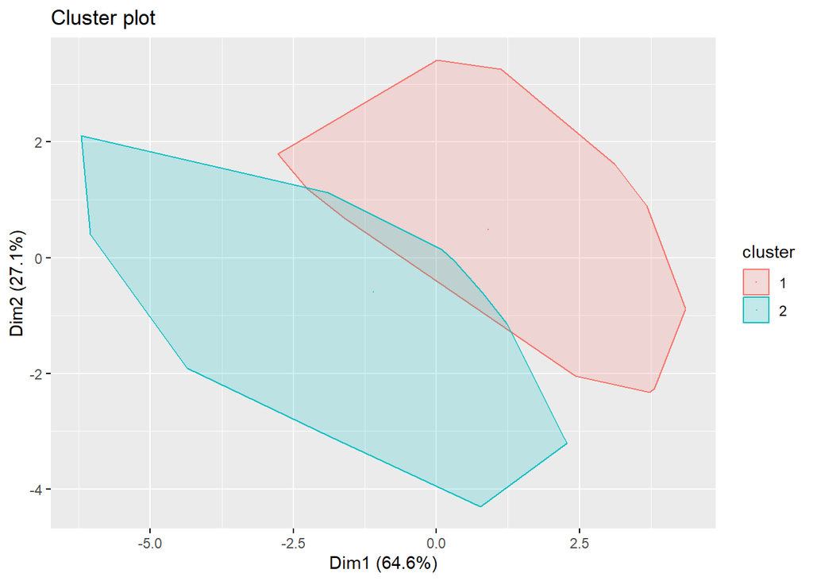

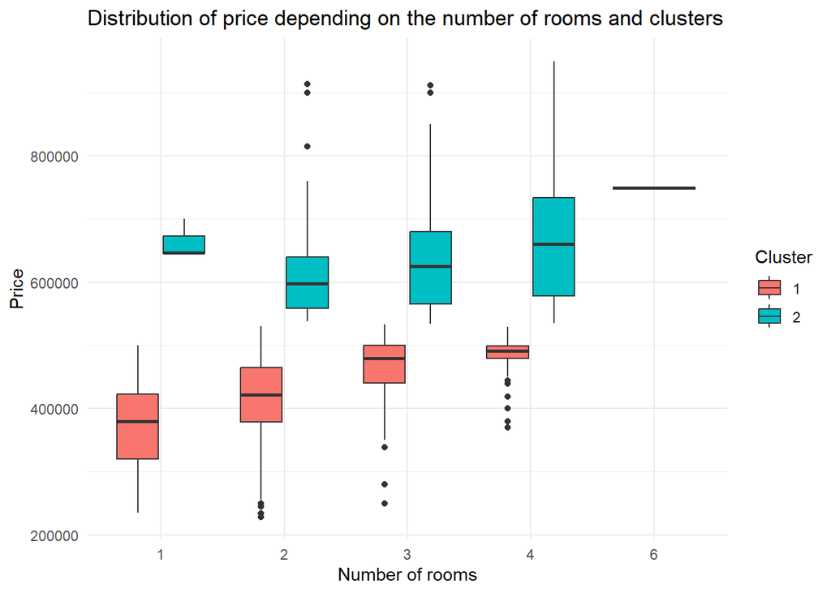

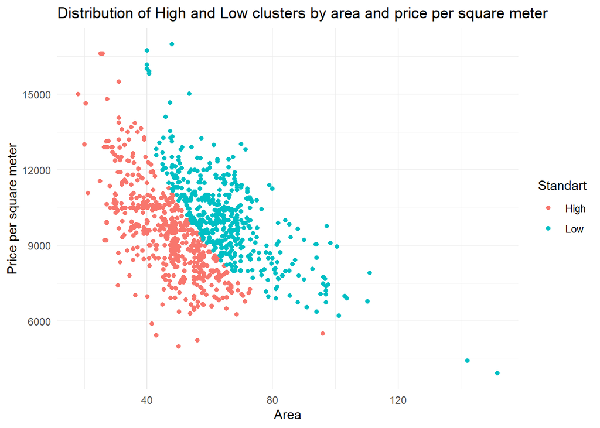

### **Results**

The result of the project was a detailed understanding of the structure of the real estate market in Lublin, as well as a comparative analysis with other cities, which will provide insight into the characteristics and trends of this segment. The data obtained can be useful to potential investors, developers and other real estate market participants in Lublin.